# ¿Quién sobrevivió al Titanic?

Autores/as

Gema Fernández-Avilés (Gema.FAviles@uclm.es)

Isidro Hidalgo (Isidro.Hidalgo@uclm.es)

Fecha de publicación

20 de enero de 2025

**Nota**

Los datos para esta historia están sacados de la competición de kaggle [Titanic - Machine Learning from Disaster](https://www.kaggle.com/competitions/titanic). Los datasets de entrenamiento y test se encuentran en el objeto `titanic` del paquete `titanic`.

```r
if (!require(titanic)){install.packages("titanic")}
```

Mi colega de departamento se ha picado con el departamento vecino, y se han apostado que ganaban el próximo datathon de GAIA-X. No pasaría nada, sería su problema, si no me hubiera pedido que le ayudara con el análisis exploratorio, que está mal de tiempo… lo de siempre… ¡¿Pero por qué no pueden dejarme tranquilo?!

# 1 Entender el contexto

**Cómo definir el propósito y la audiencia de tu análisis**

En este caso, puesto que el objetivo de mi colega es la predicción, lo primero que vamos a hacer es un análisis exploratorio, para ver las relaciones entre las variables del conjunto de datos. Luego ya se apañará mi compañero para modelizar… ¡a ver si se piensa que lo voy a hacer todo yo!

```r
#library(titanic)
library(tidyverse)
if (!require(readxl)){install.packages("readxl")}
library(readxl)
library(skimr)
library(explore)
library(ggmosaic)
library(ggalluvial)
library(visdat)
```

```r
titanic <- read_xlsx("data/titanic.xlsx")
head(titanic, 3)
```

```
# A tibble: 3 × 12
  PassengerId Survived Pclass Name    Sex     Age SibSp Parch Ticket  Fare Cabin
        <dbl>    <dbl>  <dbl> <chr>   <chr> <dbl> <dbl> <dbl> <chr>  <dbl> <chr>
1           1        0      3 Braund… male     22     1     0 A/5 2…  7.25 <NA>
2           2        1      1 Cuming… fema…    38     1     0 PC 17… 71.3  C85
3           3        1      3 Heikki… fema…    26     0     0 STON/…  7.92 <NA>
# ℹ 1 more variable: Embarked <chr>
```

```r
# Podríamos descargarlo directamente del paquete titanic:
# titanic <- titanic::titanic_train
```

```r
names(titanic)[1:6] <- c("id", "supervivencia", "clase", "nombre", "sexo", "edad")
head(titanic, 3)
```

```
# A tibble: 3 × 12
     id supervivencia clase nombre    sexo   edad SibSp Parch Ticket  Fare Cabin
  <dbl>         <dbl> <dbl> <chr>     <chr> <dbl> <dbl> <dbl> <chr>  <dbl> <chr>
1     1             0     3 Braund, … male     22     1     0 A/5 2…  7.25 <NA>
2     2             1     1 Cumings,… fema…    38     1     0 PC 17… 71.3  C85
3     3             1     3 Heikkine… fema…    26     0     0 STON/…  7.92 <NA>
# ℹ 1 more variable: Embarked <chr>
```

Un paquete muy interesante para el análisis exploratorio es `skim`

```r
skim(titanic)
```

Data summary

| Name | titanic |
| --- | --- |
| Number of rows | 891 |
| Number of columns | 12 |
| _______________________ |  |
| Column type frequency: |  |
| character | 5 |
| numeric | 7 |
| ________________________ |  |
| Group variables | None |

**Variable type: character**

| skim_variable | n_missing | complete_rate | min | max | empty | n_unique | whitespace |
| --- | --- | --- | --- | --- | --- | --- | --- |
| nombre | 0 | 1.00 | 12 | 82 | 0 | 891 | 0 |
| sexo | 0 | 1.00 | 4 | 6 | 0 | 2 | 0 |
| Ticket | 0 | 1.00 | 3 | 18 | 0 | 681 | 0 |
| Cabin | 687 | 0.23 | 1 | 15 | 0 | 147 | 0 |
| Embarked | 2 | 1.00 | 1 | 1 | 0 | 3 | 0 |

**Variable type: numeric**

| skim_variable | n_missing | complete_rate | mean | sd | p0 | p25 | p50 | p75 | p100 | hist |
| --- | --- | --- | --- | --- | --- | --- | --- | --- | --- | --- |
| id | 0 | 1.0 | 446.00 | 257.35 | 1.00 | 223.50 | 446.00 | 668.5 | 891.00 | ▇▇▇▇▇ |
| supervivencia | 0 | 1.0 | 0.38 | 0.49 | 0.00 | 0.00 | 0.00 | 1.0 | 1.00 | ▇▁▁▁▅ |
| clase | 0 | 1.0 | 2.31 | 0.84 | 1.00 | 2.00 | 3.00 | 3.0 | 3.00 | ▃▁▃▁▇ |
| edad | 177 | 0.8 | 29.70 | 14.53 | 0.42 | 20.12 | 28.00 | 38.0 | 80.00 | ▂▇▅▂▁ |
| SibSp | 0 | 1.0 | 0.52 | 1.10 | 0.00 | 0.00 | 0.00 | 1.0 | 8.00 | ▇▁▁▁▁ |
| Parch | 0 | 1.0 | 0.38 | 0.81 | 0.00 | 0.00 | 0.00 | 0.0 | 6.00 | ▇▁▁▁▁ |
| Fare | 0 | 1.0 | 32.20 | 49.69 | 0.00 | 7.91 | 14.45 | 31.0 | 512.33 | ▇▁▁▁▁ |

# 2 Elegir una visualización adecuada

**Selección de gráficos y visualizaciones que mejor representen tus datos.**

## 2.1 ¿Hombre o mujer?

Una pregunta que podemos hacernos enseguida es: ¿influyó el sexo en la supervivencia?

Si usamos un **diagrama de mosaico**, que es un método gráfico para visualizar datos de dos o más variables cualitativas, podemos tener una visión general de los datos y reconocer relaciones entre diferentes variables cualitativas.

Veamos la `supervivencia` de los pasajeros del Titanic en función del `sexo` (ambas variables cualitativas).

**Tu turno**

Completa las partes del código señaladas por `_____` o `xxxxx` para obtener el resultado propuesto.

### 2.1.1 Paso 1: Convierte las variables a `factor`

```r
titanic_mosaico <- titanic |>                  # Carga el dataset titanic_mosaico
  select(clase, sexo, edad, supervivencia) |>  # Selecciona las columnas clase, sexo, edad y supervivencia
  mutate_all(as.factor)                        # Convierte todas las columnas seleccionadas a factores
```

### 2.1.2 Paso 2: Primer mosaico con las variables `supervivencia` y `sexo`

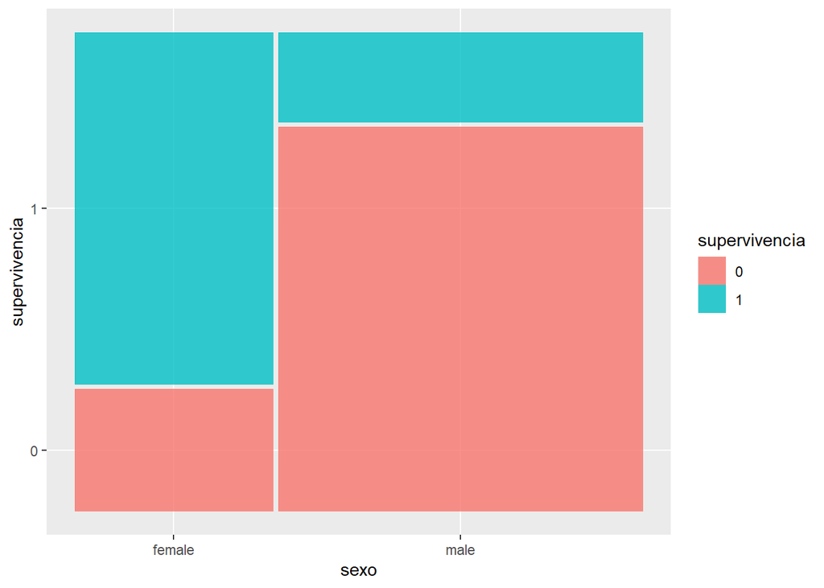

```r
mosaico2 <- ggplot(data = titanic_mosaico) +        # Crea un gráfico con el dataset titanic_mosaico
  geom_xxxxx(aes(x = product(supervivencia, sexo),  # Combina supervivencia y sexo en el eje x
                  fill = supervivencia))            # Colorea los mosaicos según la variable supervivencia

mosaico2
```

## 2.2 ¿A qué clase perteneces?¿Eres miembro de la tripulación? ¿Hombre o mujer?

Avanzamos un poco más con los gráficos de mosaico, representando tres variables cualitativas.

Veamos la `supervivencia` de los pasajeros del Titanic en función del `sexo` y la `clase` (todas las variables cualitativas)

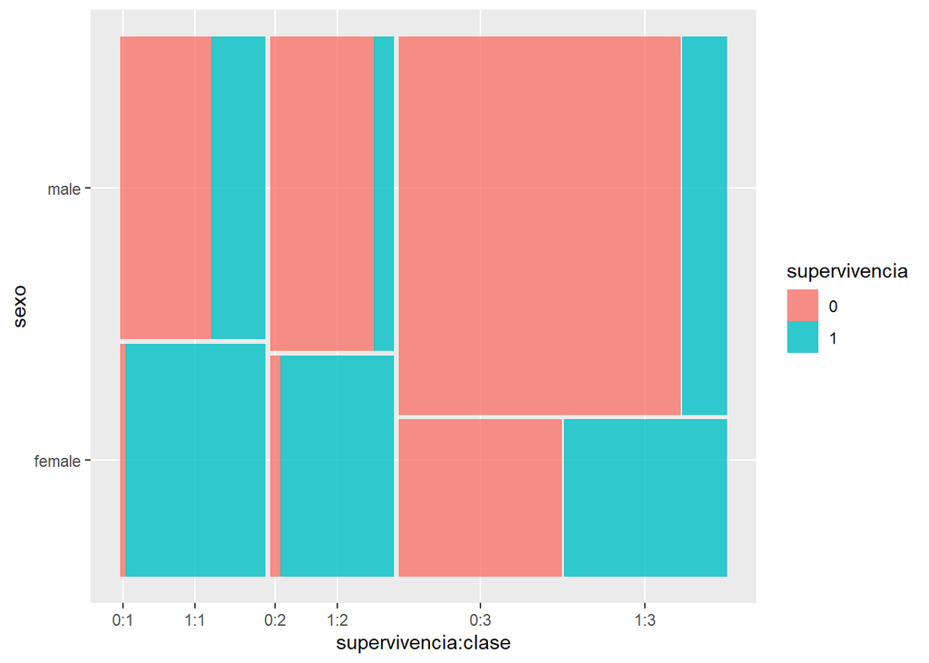

```r
mosaico3 <- ggplot(data = titanic_mosaico) +
  geom_mosaic(aes(x = product(supervivencia, sexo, clase),
                  fill = supervivencia))
mosaico3
```

# 3 Eliminar el desorden. Enfocar la atención

El gráfico anterior es muy complicado de interpretar y exige un enorme esfuerzo del lector, por su elevada carga cognitiva. **¿Podemos facilitarle la vida?**, porque… ¡de eso se trata en visualización!

## 3.1 El diagrama de flujo

Un diagrama de flujo es un gráfico que muestra los pasos de un proceso de una manera visual y fácil de entender, por tanto, este tipo de gráficos permitirán visualizar el flujo de los datos a través de las variables que analizamos. Véase como mejora la interpretabilidad de los datos cualitativos respecto al mosaico con tres variables cualitativas.

Analizamos las mismas variables cualitativas: `supervivencia`, `sexo` y `clase`, pero ahora **el gráfico es mucho más fácil de leer y, por tanto, estamos facilitando el mensaje**. En esto consiste eliminar el desorden.

[figure not shown]

```r
tabla_titanic <- titanic |>
  group_by(clase, sexo, supervivencia) |>  # Agrupa los datos por clase, sexo y supervivencia
  count()                                  # Cuenta el número de ocurrencias en cada grupo

flujo <- ggplot(tabla_titanic,             # Crea un gráfico con la tabla agrupada
       aes(axis1 = sexo,                   # Define el primer eje como sexo
           axis2 = clase,                  # Define el segundo eje como clase
           axis3 = supervivencia,          # Define el tercer eje como supervivencia
           y = n)) +                       # Usa la columna n para la altura de los estratos
  geom_alluvium(aes(fill = sexo)) +        # Añade las corrientes (alluviums) o flujos coloreadas por sexo
  geom_stratum() +                         # Añade los estratos (strata) o categorías
  geom_text(stat = "stratum",              # Añade etiquetas a los estratos
            aes(label = after_stat(stratum))) +  # Usa el nombre del estrato como etiqueta
  scale_x_discrete(limits = c("clase", "sexo", "supervivencia"),  # Define los límites de los ejes x
                   expand = c(.1, .1)) +  # Añade espacio alrededor de los ejes
  scale_fill_viridis_d() +                # Aplica una paleta de colores viridis
  labs(title = "Las mujeres de primera clase tuvieron preferencia",
       y = "Frecuencia") +
  theme_minimal() +
  theme(legend.position = "none",  # Elimina la leyenda
        axis.title.y = element_text(hjust = 1))

flujo  # Muestra el gráfico
```

# 4 Contar una historia

**Cómo narrar una historia convincente con tus datos.**

Hasta ahora hemos visto el **planteamiento**, en el que proporcionamos el contexto: un colega de departamento nos ha pedido ayuda. Si es científico, como nosotros, podemos utilizar todo nuestro arsenal gráfico sin problemas. Como quiere hacer predicción, está interesado en ver la influencia de las variables en la `supervivencia`.

## 4.1 Para pensar

Si se hundiera hoy en día el Titanic, ¿habría cambiado la influencia de alguna variable en el modelo? ¿Tendríamos una visualización más confusa en el gráfico de flujo?

¿Cómo podría modelizarse la supervivencia, dadas las conclusiones que hemos sacado?